# Data-Driven Risk Modelling of Hard Drive Failures

2026-11-02

## 1. Overview

This report models short-horizon and lifetime hard drive failure risk using a 2021-2022 sample of the Backblaze hard drive dataset (top 15 models by fleet size, ~197k drives, ~127M valid drive-day observations), to inform drive replacement and warranty decisions. Four research questions are addressed with the module’s core methods - classification, time-series feature engineering, clustering, and regression - with Kaplan-Meier and Cox proportional hazards survival analysis used throughout as a supporting tool for handling censoring and cross-validating the core-method findings. See `../README.md` for full data provenance, pipeline documentation, and stated assumptions/limitations.

## 2. Data & Sample

```
## Drives: 197131 | Models: 15 | Failures observed: 4084 (2.072%)
```

The fleet is dominated by a small number of failures against a very large population, consistent with hard drives being a genuinely reliable component in aggregate - the central modelling challenge throughout this report is extreme class imbalance, not lack of data volume.

## 3. Supporting Survival Analysis (Kaplan-Meier & Cox)

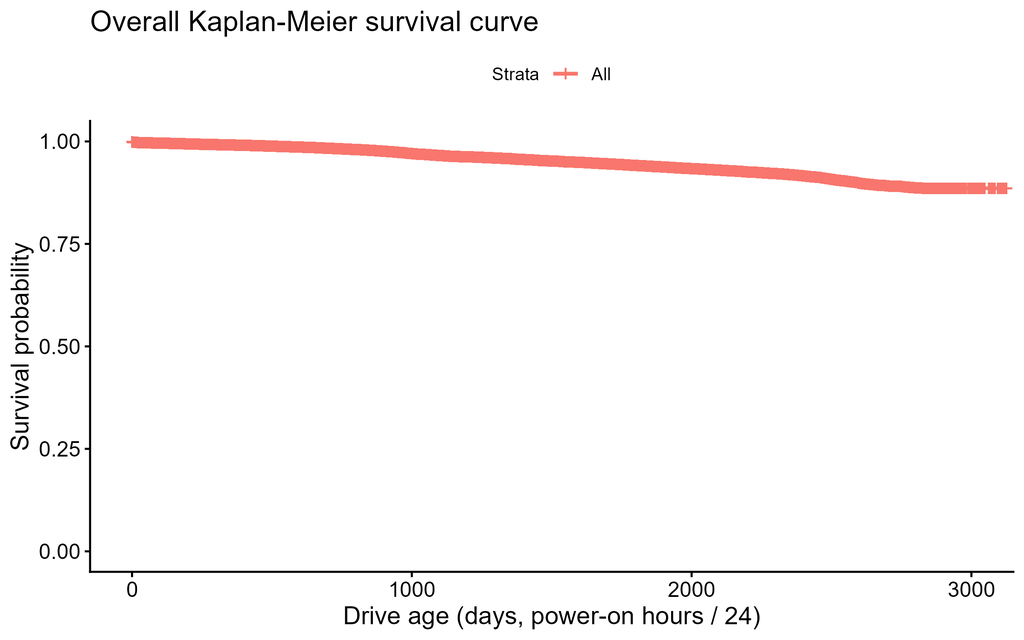

Overall Kaplan-Meier survival curve

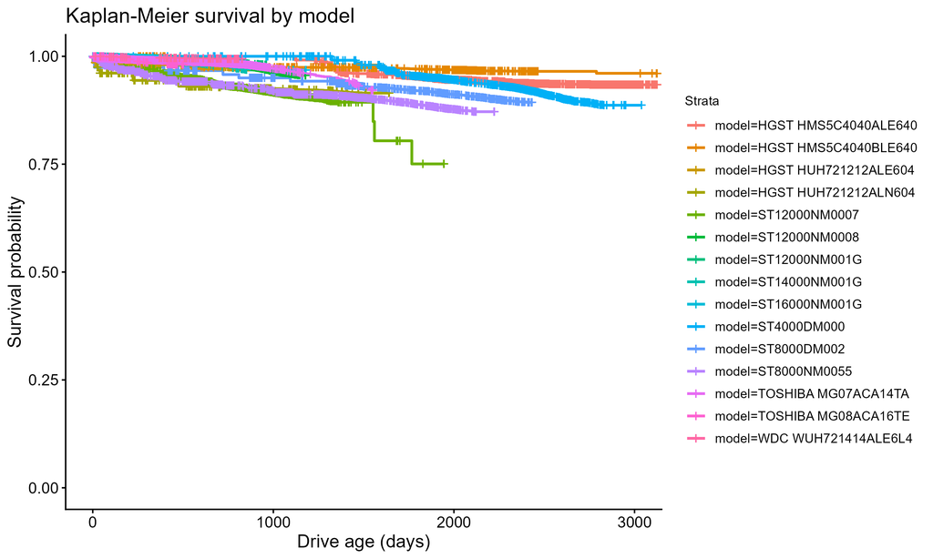

Kaplan-Meier survival by model

```
## Call:
## coxph(formula = surv_obj ~ model, data = events)
##
##   n= 197131, number of events= 4084
##
##                              coef exp(coef) se(coef)      z Pr(>|z|)
## modelHGST HMS5C4040BLE640 -0.9338    0.3931   0.1638 -5.702 1.18e-08 ***
## modelHGST HUH721212ALE604  0.6602    1.9351   0.2277  2.900  0.00373 **
## modelHGST HUH721212ALN604  0.1887    1.2077   0.1961  0.962  0.33599
## modelST12000NM0007         1.6584    5.2511   0.1974  8.400  < 2e-16 ***
## modelST12000NM0008         1.4736    4.3651   0.1933  7.622 2.50e-14 ***
## modelST12000NM001G         0.9107    2.4860   0.2089  4.360 1.30e-05 ***
## modelST14000NM001G         1.6710    5.3175   0.2038  8.197 2.46e-16 ***
## modelST16000NM001G         1.1684    3.2170   0.2234  5.230 1.70e-07 ***
## modelST4000DM000           0.7989    2.2232   0.1323  6.038 1.56e-09 ***
## modelST8000DM002           0.6022    1.8261   0.1385  4.349 1.36e-05 ***
## modelST8000NM0055          0.8673    2.3804   0.1375  6.307 2.85e-10 ***
## modelTOSHIBA MG07ACA14TA   1.0996    3.0030   0.1916  5.738 9.60e-09 ***
## modelTOSHIBA MG08ACA16TE   2.1500    8.5848   0.2260  9.512  < 2e-16 ***
## modelWDC WUH721414ALE6L4   0.1202    1.1277   0.2526  0.476  0.63424
## ---
## Signif. codes:  0 '***' 0.001 '**' 0.01 '*' 0.05 '.' 0.1 ' ' 1
##
##                           exp(coef) exp(-coef) lower .95 upper .95
## modelHGST HMS5C4040BLE640    0.3931     2.5440    0.2852    0.5418
## modelHGST HUH721212ALE604    1.9351     0.5168    1.2386    3.0234
## modelHGST HUH721212ALN604    1.2077     0.8280    0.8222    1.7739
## modelST12000NM0007           5.2511     0.1904    3.5661    7.7321
## modelST12000NM0008           4.3651     0.2291    2.9883    6.3763
## modelST12000NM001G           2.4860     0.4023    1.6509    3.7436
## modelST14000NM001G           5.3175     0.1881    3.5661    7.9290
## modelST16000NM001G           3.2170     0.3109    2.0762    4.9845
## modelST4000DM000             2.2232     0.4498    1.7153    2.8814
## modelST8000DM002             1.8261     0.5476    1.3921    2.3954
## modelST8000NM0055            2.3804     0.4201    1.8180    3.1167
## modelTOSHIBA MG07ACA14TA     3.0030     0.3330    2.0626    4.3720
## modelTOSHIBA MG08ACA16TE     8.5848     0.1165    5.5122   13.3701
## modelWDC WUH721414ALE6L4     1.1277     0.8868    0.6874    1.8500
##
## Concordance= 0.617  (se = 0.005 )
## Likelihood ratio test= 912.3  on 14 df,   p=<2e-16
## Wald test            = 699  on 14 df,   p=<2e-16
## Score (logrank) test = 810.1  on 14 df,   p=<2e-16
```

## 4. RQ1 - Short-Horizon Failure Classification

*Can early-life SMART attributes predict whether a drive will fail within the next 30 days, using a snapshot of its current SMART readings?*

```
## Logistic regression AUC: 0.8505
```

```
## Elastic-net logistic AUC: 0.7887
```

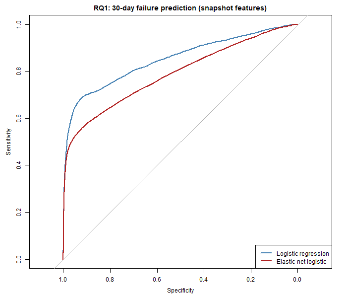

Both classifiers substantially beat chance. The plain logistic regression baseline (log1p-transformed, standardized, non-collinear raw SMART predictors) reaches **AUC 0.85**, slightly ahead of the elastic-net model (**AUC 0.79**) fit on the full raw+normalized attribute set - regularization handles the collinearity in the fuller feature set well, but doesn’t outperform a carefully preprocessed simpler model here. This is a reasonable, reportable result: SMART snapshots alone carry real short-horizon failure signal, well above the ~50% chance line.

## 5. RQ2 - Value of Time-Series Features

*Do rolling time-series SMART features (7/30-day mean, volatility, and slope) improve on snapshot-only prediction?*

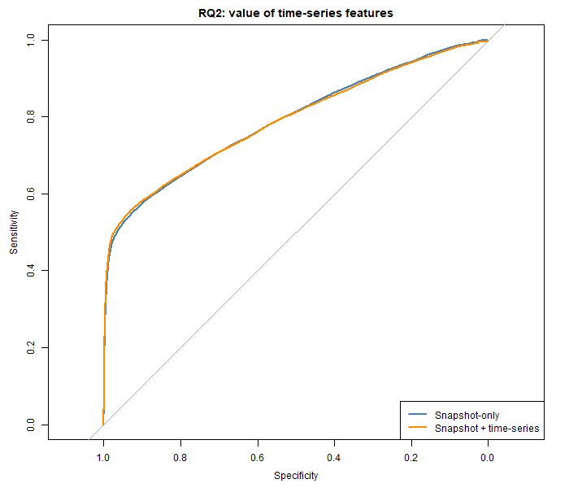

Adding rolling features left ranking ability essentially unchanged (AUC 0.791 snapshot-only vs. 0.790 with time-series features added) but improved precision-recall performance (PR-AUC 0.489 -> 0.509). Interpretation: a drive’s *current* SMART levels already capture most of the information needed to separate failing from healthy drives in a 30-day window; the *trend* information adds comparatively little extra ranking power, but does help sharpen the precision/recall trade-off - useful for operational decisions (e.g. setting an alert threshold) even though it doesn’t move the headline AUC much.

## 6. RQ3 - Degradation-Pattern Clustering

*Are there distinct clusters of drives with similar degradation trajectories, and do they carry materially different failure risk?*

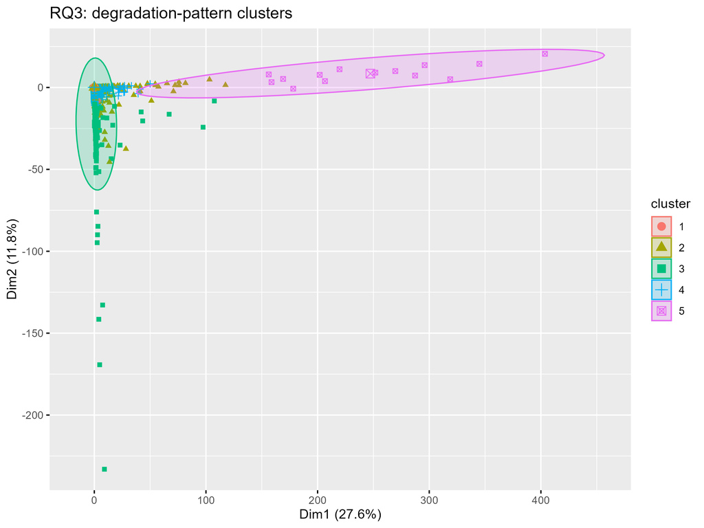

Cluster scatter (PCA projection)

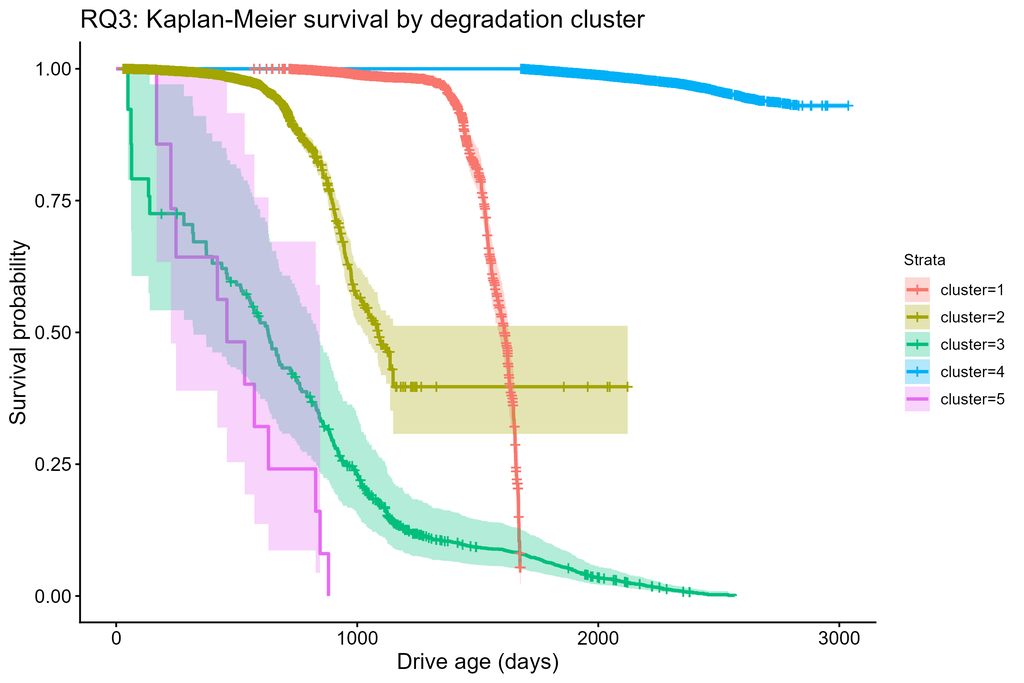

Kaplan-Meier survival by cluster

Failure rate by degradation cluster (k=5, chosen by silhouette score)

| cluster | n_drives | failure_rate |
| --- | --- | --- |
| 1 | 51616 | 0.0113 |
| 2 | 22337 | 0.0306 |
| 3 | 541 | 0.6895 |
| 4 | 42146 | 0.0311 |
| 5 | 11 | 1.0000 |

This is the strongest result in the report. K-means on rolling degradation features (silhouette-selected k=5) separates drives into groups with failure rates ranging from **~1.1% (largest, healthy cluster) up to 68.9% and 100%** in two small, sharply distinct clusters - a difference of nearly two orders of magnitude. The Cox score test (log-rank-equivalent, robust to the left-truncated time axis used throughout) confirms the survival curves differ across clusters far beyond chance (p < 0.001). Practically: unsupervised degradation patterns alone, with no failure label used in fitting, recover a highly actionable high-risk segment - exactly the kind of signal that could drive targeted monitoring or early replacement.

## 7. RQ4 - Expected Loss & Cost Implications

*How does predicted failure risk translate into expected replacement costs across drive models and coverage durations?*

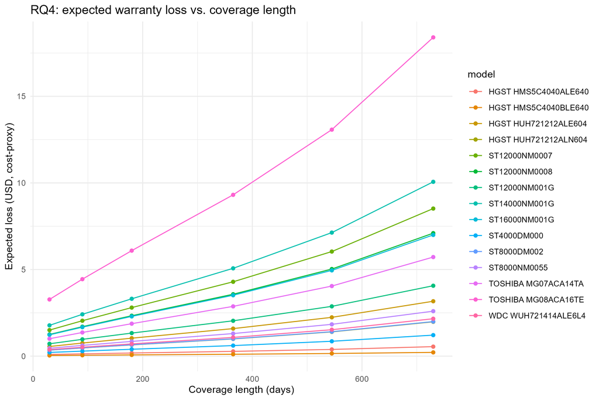

Expected loss by model and coverage length (head; cost proxy: $25/TB)

| model | coverage_days | capacity_bytes | capacity_tb | replacement_cost_usd | p_fail_within_coverage | expected_loss_usd |
| --- | --- | --- | --- | --- | --- | --- |
| HGST HMS5C4040ALE640 | 30 | 4.000787e+12 | 4.0008 | 100.0197 | 0.0010 | 0.0957 |
| HGST HMS5C4040BLE640 | 30 | 4.000787e+12 | 4.0008 | 100.0197 | 0.0004 | 0.0376 |
| HGST HUH721212ALE604 | 30 | 1.200014e+13 | 12.0001 | 300.0035 | 0.0018 | 0.5549 |
| HGST HUH721212ALN604 | 30 | 1.200014e+13 | 12.0001 | 300.0035 | 0.0012 | 0.3465 |
| ST12000NM0007 | 30 | 1.200014e+13 | 12.0001 | 300.0035 | 0.0050 | 1.5035 |
| ST12000NM0008 | 30 | 1.200014e+13 | 12.0001 | 300.0035 | 0.0042 | 1.2503 |
| ST12000NM001G | 30 | 1.200014e+13 | 12.0001 | 300.0035 | 0.0024 | 0.7127 |
| ST14000NM001G | 30 | 1.400052e+13 | 14.0005 | 350.0130 | 0.0051 | 1.7762 |
| ST16000NM001G | 30 | 1.600090e+13 | 16.0009 | 400.0225 | 0.0031 | 1.2293 |
| ST4000DM000 | 30 | 4.000787e+12 | 4.0008 | 100.0197 | 0.0021 | 0.2125 |
| ST8000DM002 | 30 | 8.001563e+12 | 8.0016 | 200.0391 | 0.0017 | 0.3492 |
| ST8000NM0055 | 30 | 8.001563e+12 | 8.0016 | 200.0391 | 0.0023 | 0.4551 |

## 8. Discussion

**Limitations.**

- **Observational, enterprise-only population.** Backblaze operates data centre workloads; consumer usage patterns (temperature, vibration, power cycling) differ and these results should not be extrapolated to consumer drives without validation on consumer-representative data.
- **Reduced sample.** This analysis uses a 2021-2022, top-15-model subset of the full 2016-2022 Backblaze dataset (see `../README.md`) for tractability on commodity hardware; a production deployment would revisit that scoping.
- **SMART attribute coverage varies by manufacturer.** Feature engineering was restricted to attributes with broad cross-manufacturer coverage; some vendor-specific signal may have been left out.
- **Correlational, not causal.** SMART/degradation associations with failure are statistical associations from observational data, not causal effects.
- **RQ4’s cost proxy ($/TB) is illustrative**, not real manufacturer or retail replacement pricing - the loss *curves and relative ordering* across models are the meaningful output, not the absolute dollar figures.
- **Cox proportional-hazards assumption is formally violated** per the Schoenfeld residual test (Section 3), likely reflecting real time-varying risk (e.g. infant-mortality vs. wear-out failure modes) rather than a modelling error; RQ4’s loss projections should be read as first-order approximations, not precise hazard forecasts.
- **Left-truncation** is handled via power-on hours as the true age axis (robust to drives already in service before the observation window began), but drive removals for reasons other than failure (e.g. fleet migration) are not distinguishable from failure-free censoring in this dataset.

**Ethical and sustainability implications.** Acting on model-level risk could create an incentive to discontinue or avoid lower-reliability models - a plausible reliability-improving effect. It could also concentrate replacement and e-waste around specific models or degradation signatures in ways worth monitoring, and predictive early-replacement signals raise a genuine tension between encouraging premature hardware replacement (a sustainability cost) and running drives closer to actual failure (a data-loss risk). Neither is assessed quantitatively here, but both are live considerations were this analysis to inform real replacement policy.